# Estudios de Informática, Multimedia y Telecomunicaciones

# Minería de datos: PEC2

Autor: Jesús González Leal

Abril 2021

# 1 Introducción

## 1.1 Presentación

Esta prueba de evaluación continuada cubre los módulo 5 y 6 del programa de la asignatura.

## 1.2 Competencias

Las competencias que se trabajan en esta prueba son:

- Uso y aplicación de las TIC en el ámbito académico y profesional
- Capacidad para innovar y generar nuevas ideas.
- Capacidad para evaluar soluciones tecnológicas y elaborar propuestas de proyectos teniendo en cuenta los recursos, las alternativas disponibles y las condiciones de mercado.
- Conocer las tecnologías de comunicaciones actuales y emergentes, así como saberlas aplicar convenientemente para diseñar y desarrollar soluciones basadas en sistemas y tecnologías de la información.
- Aplicación de las técnicas específicas de ingeniería del software en las diferentes etapas del ciclo de vida de un proyecto.
- Capacidad para aplicar las técnicas específicas de tratamiento, almacenamiento y administración de datos.
- Capacidad para proponer y evaluar diferentes alternativas tecnológicas para resolver un problema concreto.
- Capacidad de utilizar un lenguaje de programación.
- Capacidad para desarrollar en una herramienta IDE.
- Capacidad de plantear un proyecto de minería de datos.

## 1.3 Objetivos

En esta PEC trabajaremos la generación, interpretación y evaluación de un modelo de agregación y de un modelo donde generaremos reglas de asociación con el software de practicas. No perderemos de vista las fases de preparación de los datos, calidad del modelo y extracción inicial del conocimiento.

## 1.4 Descripción de la PEC a realizar

La prueba está estructurada en 2 ejercicios teóricos y 3 ejercicios prácticos.

## 1.5 Recursos

Para realizar esta práctica recomendamos como punto de partida la lectura de los siguientes documentos:

- Módulos 5 y 6 del material didáctico.
- El aula laboratorio de R para resolver dudas o problemas.
- RStudio Cheat Sheet: Disponible en el aula Laboratorio de Minería de datos.
- R Base Cheat Sheet: Disponible en el aula Laboratorio de Minería de datos.

## 1.6 Formato y fecha de entrega

El formato de entrega es: usernameestudiant-PAC1.html (pdf o word) y rmd. Fecha de Entrega: 21/04/2021. Se tiene que depositar la PEC en el buzón de entregas del aula.

## 1.7 Nota: Propiedad intelectual

A menudo es inevitable, al producir una obra multimedia, hacer uso de recursos creados por terceras personas. Es por lo tanto comprensible hacerlo en el marco de una práctica de los estudios de Informática, Multimedia y Telecomunicación de la UOC, siempre y cuando esto se documente claramente y no suponga plagio en la práctica.

Por lo tanto, al presentar una práctica que haga uso de recursos ajenos, se debe presentar junto con ella un documento en qué se detallen todos ellos, especificando el nombre de cada recurso, su autor, el lugar dónde se obtuvo y su estatus legal: si la obra está protegida por el copyright o se acoge a alguna otra licencia de uso (Creative Commons, licencia GNU, GPL …). El estudiante deberá asegurarse de que la licencia no impide específicamente su uso en el marco de la práctica. En caso de no encontrar la información correspondiente tendrá que asumir que la obra está protegida por copyright.

Deberéis, además, adjuntar los ficheros originales cuando las obras utilizadas sean digitales, y su código fuente si corresponde.

# 2 Ejercicio 1

## 2.1 Enunciado

1. Explica de forma resumida cual es el objetivo de los métodos de agregación. Relaciona la respuesta con un ejemplo.
2. Razona si tiene sentido aplicar un método de agregación al ejemplo que pusiste en la PEC1. Si lo tiene, comenta como se podría aplicar y que tipo de resultados se podrían obtener. Si no lo tiene, reformula el problema para que si lo tenga.

## 2.2 Respuesta ejercicio 1

**Respuesta 1.1.** Los métodos de agregación buscan la agrupación de los datos bajo el criterio de proximidad o distancia. Se busca agruparlos de manera que todos los componentes del grupo (o cluster), tengan características comunes, y al mismo tiempo que ese grupo sea lo más diferente posible al resto de grupos.

Como ejemplo, tomemos un dataset formado por pacientes víctimas del cancer de mama. Las observaciones incluirán datos referentes al estilo de vida de los pacientes, si son o no fumadores, el peso, la altura (de aquí podemos estimar su índice de masa corporal y detectar el sobrepeso), hipertensión, si práctican deporte con asiduidad y durante cuanto tiempo. El empleo de algún método de agregación, nos va a permitir conocer como se agrupan las observaciones del dataset, el grupo más mayoritario, y si los grupos están separados entre ellos, o más bien, si se presentan interacciones entre los grupo debido a la mezcla de observaciones de diferentes grupos.

No estamos ante un algoritmo que nos ayude a predecir a priori, pero si podemos conocer cuales son las características principales de los grupos con más observaciones.

**Respuesta 1.2.** En el ejemplo planteado en la anterior PEC, se buscaba conocer el movimiento del tráfico con el fin de poder predecir la saturación de la red de carreteras y autovías del estado. Para se utilizaba diferentes fuentes de datos:

- Datos de las operadoras principales de telefonía móvil.
- Datos provenientes de la DGT
- Datos de afectación metereológica.

El utilizar métodos de agregación con los datos nos puede servir para detectar desde el inicio las vías de tráfico que tienden a colapsarse y poder agruparlas por tipo de vía, comunidad, periodo(si se congestionan en fin de semana, entre semana o tienden siempre al colapso). Ésto ya de entrada, nos va a permitir el realizar un tipo de análisis descriptivo de los datos con el objetivo de extraer conclusiones para poder proponer planificaciones de mejora en las vías implicadas.

# 3 Ejercicio 2

## 3.1 Enunciado

1. Explica de forma resumida cual es el objetivo de los métodos de generación de reglas de asociación. Relaciona la respuesta con un ejemplo.
2. Razona si tiene sentido aplicar un método de generación de reglas de asociación al ejemplo que pusiste en la PEC1. Si lo tiene, comenta como se podría aplicar y que tipo de resultados se podrían obtener. Si no lo tiene, reformula el problema para que si lo tenga.

## 3.2 Respuesta ejercicio 2

**Respuesta 2.1.** Las reglas de asociación buscan encontrar las **dependencias** entre los atributos de un conjunto de valores de un dataset, con el fin de poder establecer reglas entre ellos. En este dominio, una transacción se refiere a cada grupo de eventos asociados. Así por ejemplo, analizando los metadatos asociados a las compras de un portal de ventas por internet, podemos definir la transacción T como la venta de un usuario, con los siguientes itemsets (Pais origen de la IP, artículo visitado, compra(S/N), tiempo visita). En este escenario, una regla de asociación que se podría descubrir sería del tipo "si Pais = España entonces visitas {lista de artículos o familia de artículos visitados}.

**Respuesta 2.2.** Usar las reglas de asociación en el ejemplo de la anterior PAC podría servir para encontrar aquellas relaciones ocultas entre las diferentes rutas de la red de carreteras del estado. Así, nos puede ayudar a determinar si la congestión de una determinada vía puede influir en que se produzca una saturación en otras.

# 4 Ejercicio 3

## 4.1 Enunciado

En este ejercicio seguiréis los pasos del ciclo de vida de un proyecto de minería de datos para el caso de un algoritmo de agregación. Lo haréis con el fichero *clientes.csv* que encontraréis adjunto. No hay que olvidarse de la fase de preparación y análisis de datos. Es muy importante explicar muy bien los resultados obtenidos.

Los ejemplos 1 y 2 se pueden tomar como un punto de partida para la realización de este ejercicio, pero se espera que la respuesta proporcionada tenga un análisis más amplio al mostrado en estos ejemplos, prestando especial atención a explicar el conocimiento que se ha adquirido tras el proceso de minería de datos.

## 4.2 Ejemplo 1: Métodos de agregación con datos autogenerados

En este ejemplo vamos a generar un conjunto de muestras aleatorias para posteriormente usar el algoritmo kmeans para agruparlas. Se crearán las muestras alrededor de dos puntos concretos. Por lo tanto, lo lógico será agrupar en dos clústers. Puesto que inicialmente, en un problema real, no se conoce cual es el número más idóneo de clústers k, vamos a probar primero con dos (el valor óptimo) y posteriormente con 4 y 8 clústers. Para evaluar la calidad de cada proceso de agregación vamos a usar la silueta media. La silueta de cada muestra evalúa como de bien o mal está clasificada la muestra en el clúster al que ha sido asignada. Para ello se usa una fórmula que tiene en cuenta la distancia a las muestras de su clúster y la distancia a las muestras del clúster vecino más cercano.

A la hora de probar el código que se muestra, es importante tener en cuenta que las muestras se generan de forma aleatoria y también que el algoritmo kmeans tiene una inicialización aleatoria. Por lo tanto, en cada ejecución se obtendrá unos resultados ligeramente diferentes.

Lo primero que hacemos es cargar la librería cluster que contiene las funciones que se necesitan

```r
library(cluster)
```

Generamos las muestras de forma aleatoria tomando como centro los puntos [0,0] y [5,5].

```r
n <- 150 # número de muestras
p <- 2   # dimensión

sigma <- 1 # varianza de la distribución
mean1 <- 0 # centro del primer grupo
mean2 <- 5 # centro del segundo grupo

n1 <- round(n/2) # número de muestras del primer grupo
n2 <- round(n/2) # número de muestras del segundo grupo

x1 <- matrix(rnorm(n1*p,mean=mean1,sd=sigma),n1,p)
x2 <- matrix(rnorm(n2*p,mean=mean2,sd=sigma),n2,p)
```

Juntamos todas las muestras generadas y las mostramos en una gráfica

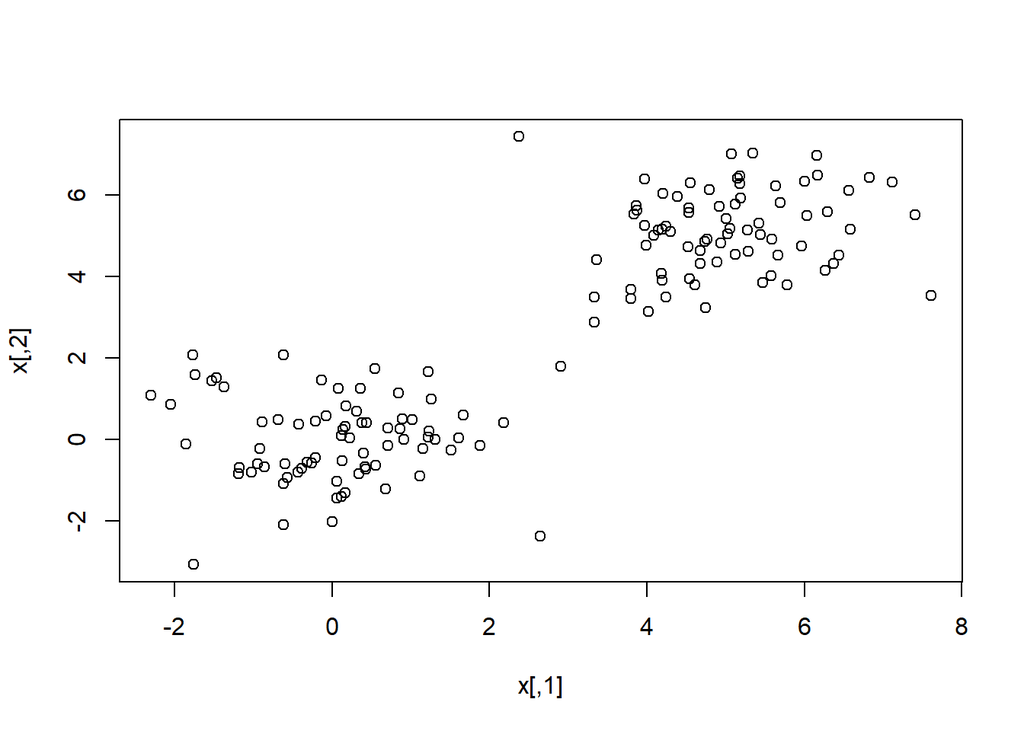

```r
x  <- rbind(x1,x2)
plot (x)
```

Como se puede comprobar las muestras están claramente separadas en dos grupos. Si se quiere complicar el problema se puede modificar los puntos centrales (mean1 y mean2) haciendo que estén más próximos y/o ampliar la varianza (sigma) para que las muestras estén más dispersas.

A continuación vamos a aplicar el algoritmo kmeans con 2, 4 y 8 clústers

```r
fit2       <- kmeans(x, 2)
y_cluster2 <- fit2$cluster

fit4       <- kmeans(x, 4)
y_cluster4 <- fit4$cluster

fit8       <- kmeans(x, 8)
y_cluster8 <- fit8$cluster
```

Las variables y_cluster2, y_cluster4 e y_cluster8 contienen para cada muestra el identificador del clúster a las que han sido asignadas. Por ejemplo, en el caso de los k=2 las muestras se han asignado al clúster 1 o al 2

```r
y_cluster2
```

```
##   [1] 1 1 1 1 1 1 1 1 1 1 1 1 1 1 1 1 1 1 1 1 1 1 1 1 1 1 1 1 1 1 1 1 1 1 1 1 1
##  [38] 1 1 1 1 1 1 1 1 1 1 1 1 1 1 1 1 1 1 1 1 1 1 1 1 1 1 1 1 1 1 1 1 1 1 1 1 1
##  [75] 1 2 2 2 2 2 2 2 2 2 2 2 2 2 2 2 2 2 2 2 2 2 2 2 2 2 2 2 2 2 2 2 2 2 2 2 2
## [112] 2 2 2 2 2 2 2 2 2 2 2 2 2 2 2 2 2 2 2 2 2 2 2 2 2 2 2 2 2 2 2 2 2 2 2 2 2
## [149] 2 2
```

Para visualizar los clústers podemos usar la función clusplot. Vemos la agrupación con 2 clústers

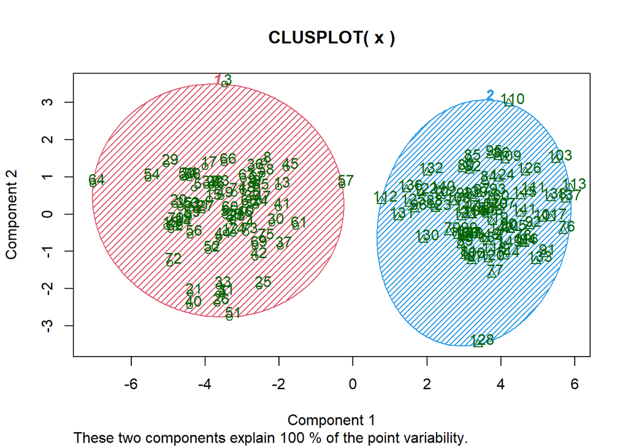

```r
clusplot(x, fit2$cluster, color=TRUE, shade=TRUE, labels=2, lines=0)
```

con 4

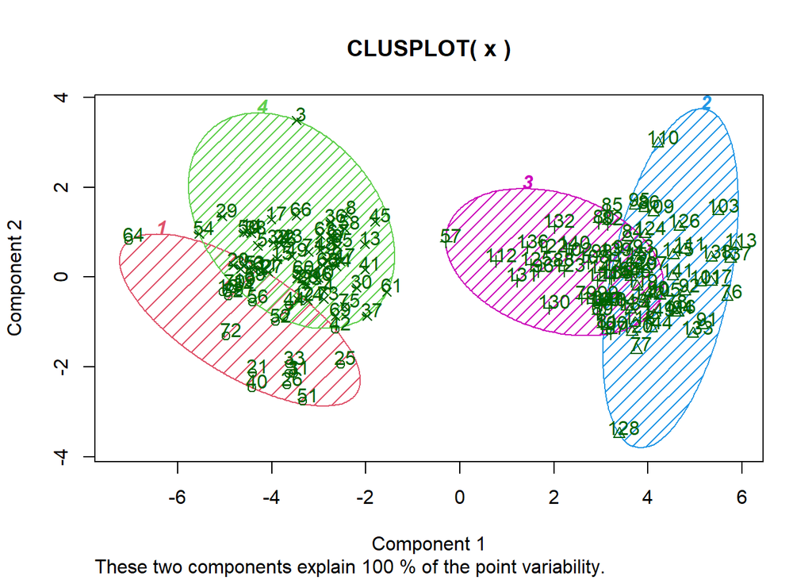

```r
clusplot(x, fit4$cluster, color=TRUE, shade=TRUE, labels=2, lines=0)
```

y con 8

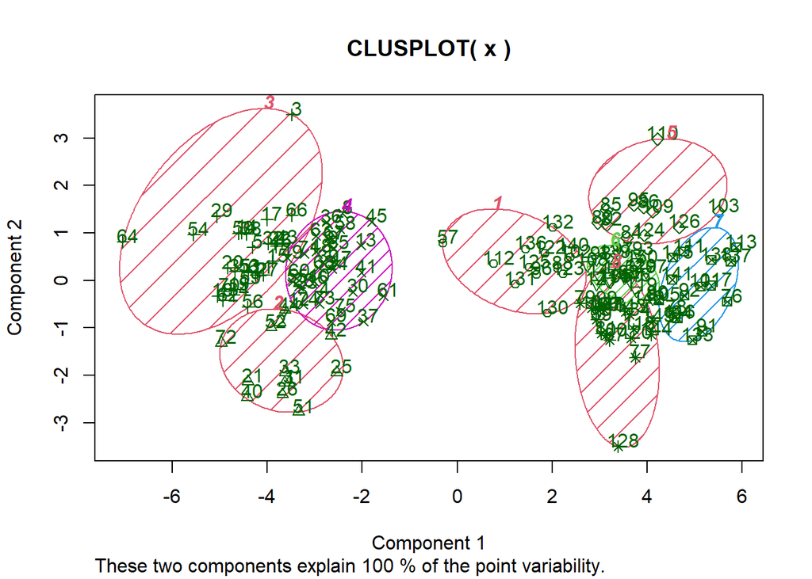

```r
clusplot(x, fit8$cluster, color=TRUE, shade=TRUE, labels=2, lines=0)
```

También podemos visualizar el resultado del proceso de agregación con el siguiente código para el caso de 2 clústers

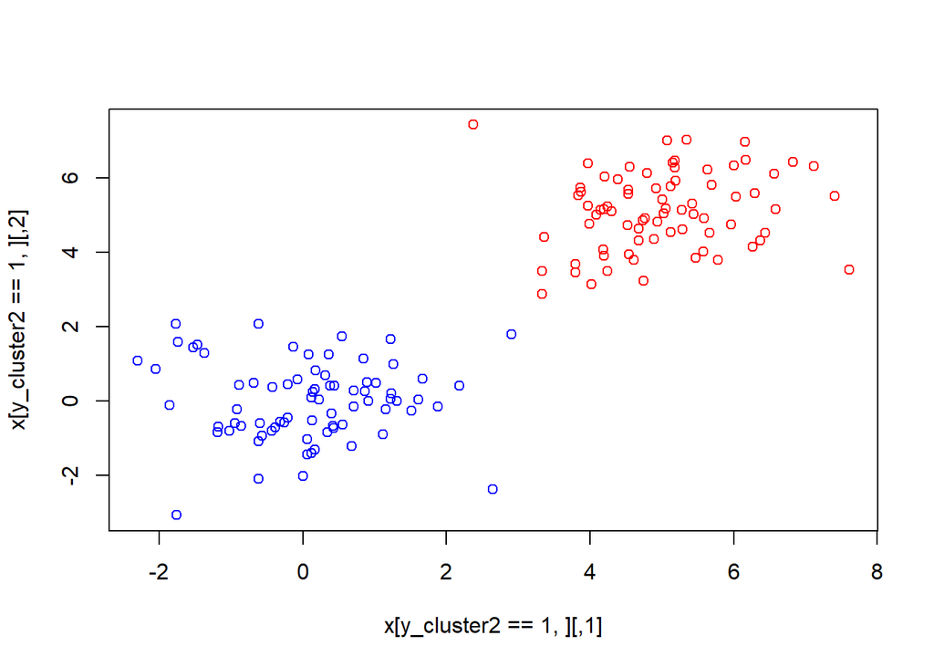

```r
plot(x[y_cluster2==1,],col='blue', xlim=c(min(x[,1]), max(x[,1])), ylim=c(min(x[,2]), max(x[,2])))
points(x[y_cluster2==2,],col='red')
```

para 4

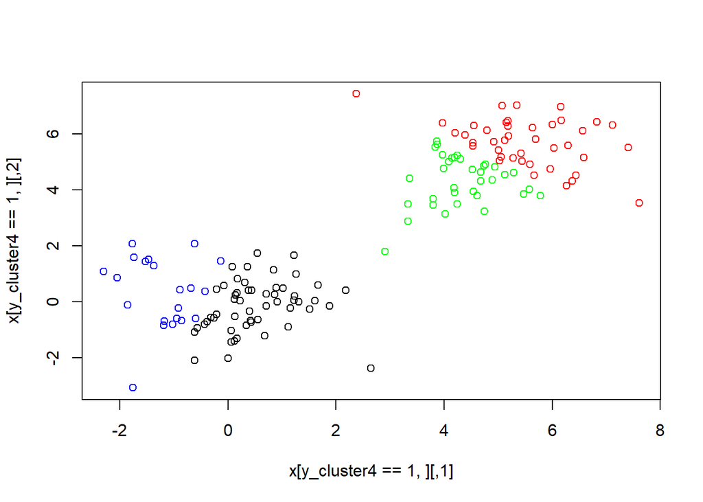

```r
plot(x[y_cluster4==1,],col='blue', xlim=c(min(x[,1]), max(x[,1])), ylim=c(min(x[,2]), max(x[,2])))
points(x[y_cluster4==2,],col='red')
points(x[y_cluster4==3,],col='green')
points(x[y_cluster4==4,],col='black')
```

y para 8

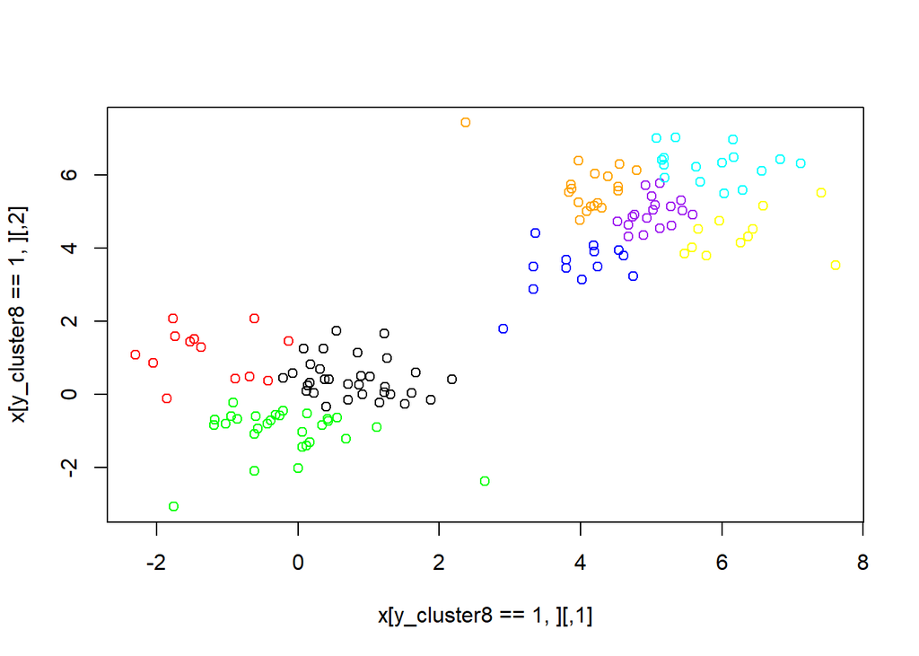

```r
plot(x[y_cluster8==1,],col='blue', xlim=c(min(x[,1]), max(x[,1])), ylim=c(min(x[,2]), max(x[,2])))
points(x[y_cluster8==2,],col='red')
points(x[y_cluster8==3,],col='green')
points(x[y_cluster8==4,],col='black')
points(x[y_cluster8==5,],col='yellow')
points(x[y_cluster8==6,],col='purple')
points(x[y_cluster8==7,],col='cyan')
points(x[y_cluster8==8,],col='orange')
```

Ahora vamos a evaluar la calidad del proceso de agregación. Para ello usaremos la función silhouette que calcula la silueta de cada muestra

```r
d  <- daisy(x)
sk2 <- silhouette(y_cluster2, d)
sk4 <- silhouette(y_cluster4, d)
sk8 <- silhouette(y_cluster8, d)
```

La función silhouette devuelve para cada muestra, el clúster dónde ha sido asignado, el clúster vecino y el valor de la silueta. Por lo tanto, calculando la media de la tercera columna podemos obtener una estimación de la calidad del agrupamiento

```r
mean(sk2[,3])
```

```
## [1] 0.7384252
```

```r
mean(sk4[,3])
```

```
## [1] 0.3255172
```

```r
mean(sk8[,3])
```

```
## [1] 0.3758049
```

Como se puede comprobar, agrupar con dos clúster es mejor que en 4 o en 8, lo cual es lógico teniendo en cuenta como se han generado los datos.

En este ejercicio no podemos sacar ninguna conclusión a partir de los clusters obtenidos puesto que los datos de partida no se corresponden con ningún problema real. En un ejemplo real tendríamos que analizar las agrupaciones obtenidas para obtener conocimiento sobre el problema a resolver.

## 4.3 Ejemplo 2: Métodos de agregación con datos reales

A continuación vamos a ver otro ejemplo de cómo se usan los modelos de agregación. Para ello usaremos el fichero *flores.csv* que encontraréis adjunto.

Cargamos el fichero y visualizamos la estructura de los datos

```r
library(cluster)
flores_data<-read.csv("flores.csv", header=T, sep=",")
colnames(flores_data) <- c("sepalLength", "sepalWidth", "petalLength", "petalWidth")
summary(flores_data)
```

```
##   sepalLength      sepalWidth     petalLength      petalWidth
##  Min.   :4.300   Min.   :2.000   Min.   :1.000   Min.   :0.100
##  1st Qu.:5.100   1st Qu.:2.800   1st Qu.:1.600   1st Qu.:0.300
##  Median :5.800   Median :3.000   Median :4.400   Median :1.300
##  Mean   :5.848   Mean   :3.051   Mean   :3.774   Mean   :1.205
##  3rd Qu.:6.400   3rd Qu.:3.300   3rd Qu.:5.100   3rd Qu.:1.800
##  Max.   :7.900   Max.   :4.400   Max.   :6.900   Max.   :2.500
```

Como podemos comprobar tenemos cuatro características, la longitud y anchura del sépalo y la longitud y anchura del pétalo.

Como inicialmente no conocemos el número óptimo de clústers, probamos con varios valores

```r
d <- daisy(flores_data)
resultados <- rep(0, 10)
for (i in c(2,3,4,5,6,7,8,9,10))
{
  fit           <- kmeans(flores_data, i)
  y_cluster     <- fit$cluster
  sk            <- silhouette(y_cluster, d)
  resultados[i] <- mean(sk[,3])
}
```

Mostramos en un gráfica los valores de las siluetas media de cada prueba para comprobar que número de clústers es el mejor

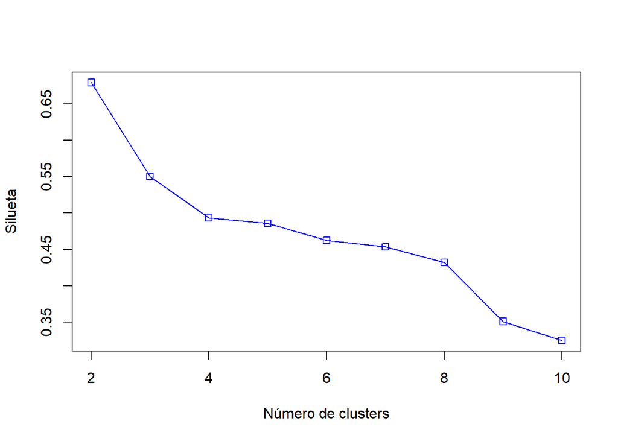

```r
plot(2:10,resultados[2:10],type="o",col="blue",pch=0,xlab="Número de clusters",ylab="Silueta")
```

El mejor valor que se obtiene es k=2.

Otro forma de evaluar cual es el mejor número de clústers es considerar el mejor modelo, aquel que ofrece la menor suma de los cuadrados de las distancias de los puntos de cada grupo con respecto a su centro (withinss), con la mayor separación entre centros de grupos (betweenss). Como se puede comprobar es una idea conceptualmente similar a la silueta. Una manera común de hacer la selección del número de clústers consiste en aplicar el método elbow (codo), que no es más que la selección del número de clústers en base a la inspección de la gráfica que se obtiene al iterar con el mismo conjunto de datos para distintos valores del número de clústers. Se seleccionará el valor que se encuentra en el “codo” de la curva

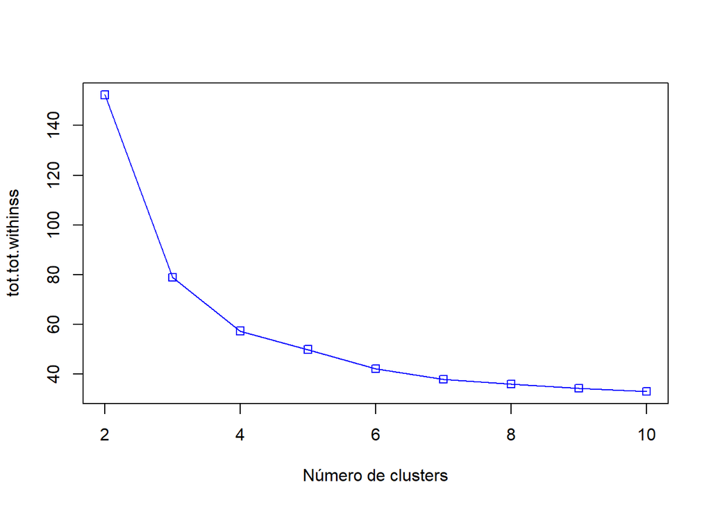

```r
resultados <- rep(0, 10)
for (i in c(2,3,4,5,6,7,8,9,10))
{
  fit           <- kmeans(flores_data, i)
  resultados[i] <- fit$tot.withinss
}
plot(2:10,resultados[2:10],type="o",col="blue",pch=0,xlab="Número de clusters",ylab="tot.tot.withinss")
```

En este caso el número óptimo de clústers es 3 o 4 que es cuando la curva comienza a estabilizarse.

También se puede usar la función *kmeansruns* del paquete fpc que ejecuta el algoritmo kmeans con un conjunto de valores, para después seleccionar el valor del número de clústers que mejor funcione de acuerdo a dos criterios: la silueta media (“asw”) y Calinski-Harabasz (“ch”).

```r
library(fpc)
fit_ch  <- kmeansruns(flores_data, krange = 1:10, criterion = "ch")
fit_asw <- kmeansruns(flores_data, krange = 1:10, criterion = "asw")
```

Podemos comprobar el valor con el que se ha obtenido el mejor resultado y también mostrar el resultado obtenido para todos los valores de k usando ambos criterios

```r
fit_ch$bestk
```

```
## [1] 3
```

```r
fit_asw$bestk
```

```
## [1] 2
```

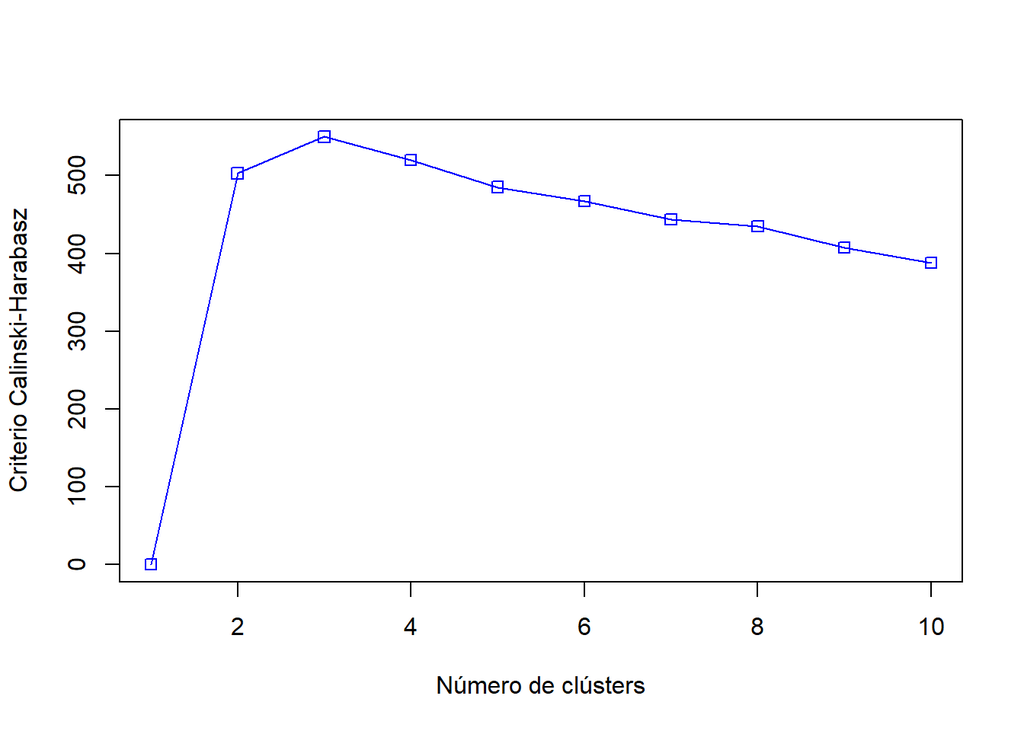

```r
plot(1:10,fit_ch$crit,type="o",col="blue",pch=0,xlab="Número de clústers",ylab="Criterio Calinski-Harabasz")
```

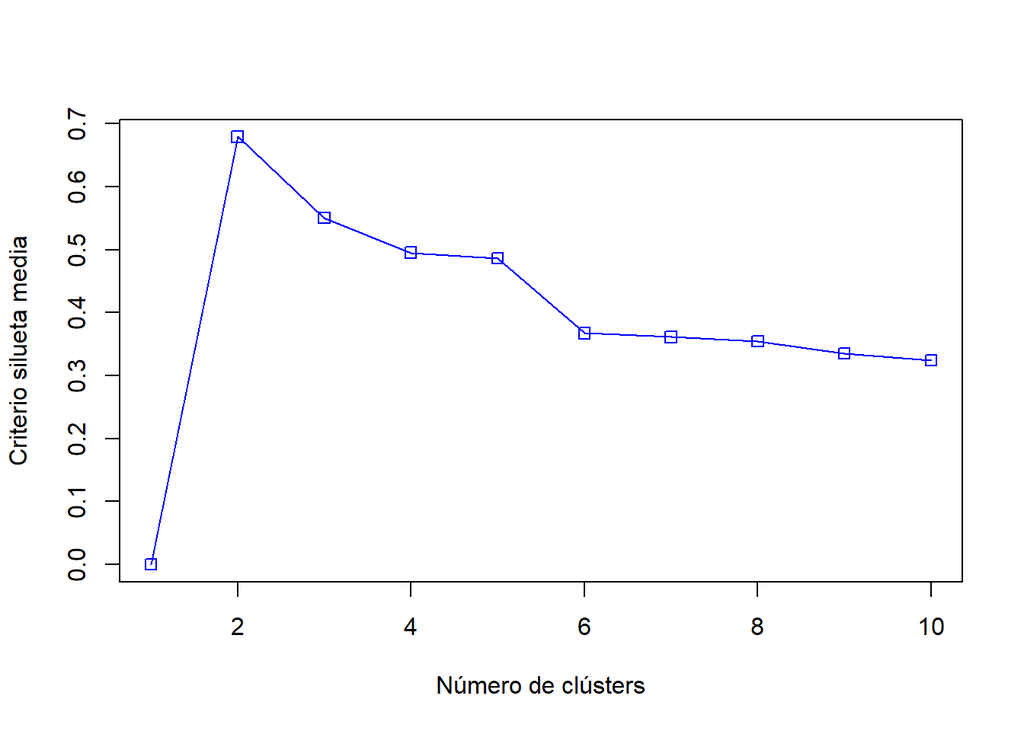

```r
plot(1:10,fit_asw$crit,type="o",col="blue",pch=0,xlab="Número de clústers",ylab="Criterio silueta media")
```

Los resultados son muy parecidos a los que hemos obtenido anteriormente. Con el criterio de la silueta media se obtienen 2 clústers y con el Calinski-Harabasz se obtienen 3.

Como se ha comprobado, conocer el número óptimo de clústers no es un problema fácil. Tampoco lo es la evaluación de los modelos de agregación.

Tras las pruebas que hemos realizado para obtener el número óptimo de clusters, hemos encontrado que el número de clusters varía según el método entre 2, 3 o 4. Vamos a estudiar los resultados encontrados con 2 y 3 clusters.

A continuación mostramos visualmente los clusters encontrados suponiendo que hay 3 clusters. Hay que tener en cuenta que nos es posible mostrar los clusters en un espacio de 4 dimensiones. Por lo tanto, mostramos los clusters entre pares de caracteríticas:

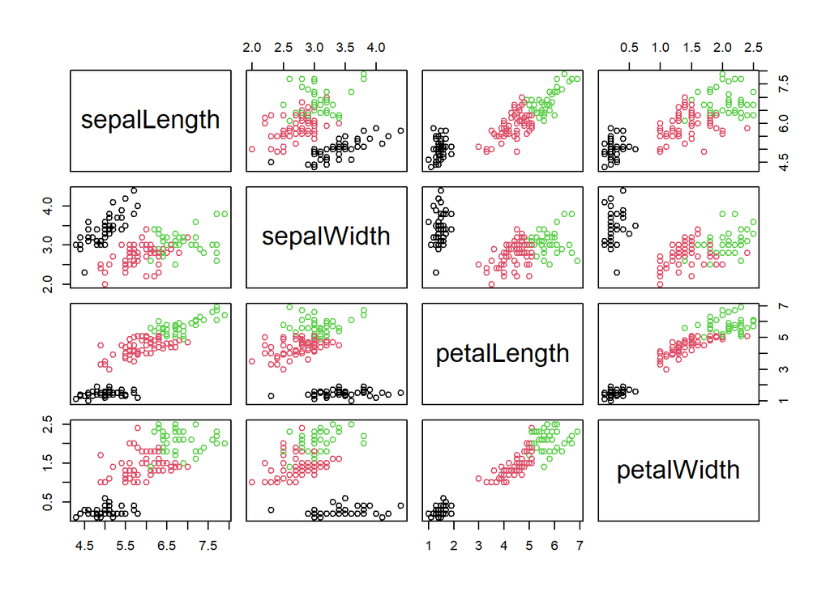

```r
cl3 <- kmeans(flores_data, 3)
with(flores_data, pairs(flores_data, col=c(1:4)[cl3$cluster]))
```

La gráfica (que puede cambiar de una ejecución a otra por el factor aleatorio del kmeans) muestra claramente que hay un cluster que está más diferenciado de los otros dos.

Una buena técnica que ayuda a entender los grupos que se han formado, es analizar las características de cada grupo:

Vamos a ahora a estudiar los conjuntos que se han obtenido con 2 clusters:

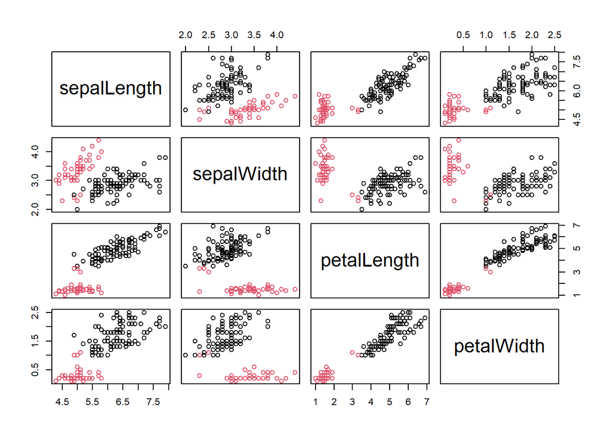

```r
cl2 <- kmeans(flores_data, 2)
with(flores_data, pairs(flores_data, col=c(1:4)[cl2$cluster]))
```

En este caso se comprueba que existen dos grupos con un frontera bastante clara y que con los valores del pétalo tenemos suficiente para diferenciar los dos grupos. Podemos describir los dos grupos como:

- Grupo 1: Valores del pétalo bajos.
- Grupo 2: Valores del pétalo alto.

Esto último lo podemos comprobar usando únicamente las dos características relacionadas con el pétalo:

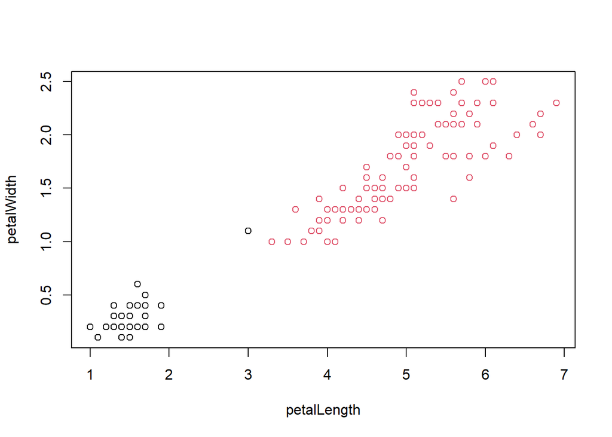

```r
cl2b <- kmeans(flores_data[c(3,4)], 2)
plot(flores_data[c(3,4)], col=cl2b$cluster)
```

## 4.4 Respuesta ejercicio 3

```r
# Lectura del fichero
df <- read.csv('clientes.csv', header = T, sep = ',', stringsAsFactors = T)
print(paste('# de filas cargadas: ', nrow(df)))
```

```
## [1] "# de filas cargadas:  200"
```

```r
str(df)
```

```
## 'data.frame':    200 obs. of  5 variables:
##  $ CustomerID        : int  1 2 3 4 5 6 7 8 9 10 ...
##  $ Genre             : Factor w/ 2 levels "Female","Male": 2 2 1 1 1 1 1 1 2 1 ...
##  $ Age               : int  19 21 20 23 31 22 35 23 64 30 ...
##  $ Annual_Income_.k..: int  15 15 16 16 17 17 18 18 19 19 ...
##  $ Spending_Score    : int  39 81 6 77 40 76 6 94 3 72 ...
```

### 4.4.1 Exploración de datos

Tenemos un dataset compuesto por 5 variables, una de ellas categórica binaria (‘Genre’), y el resto numéricas.

```r
print(paste('Número de valores nulos encontrados: ', (which(is.na.data.frame(df) ==T))))
```

```
## [1] "Número de valores nulos encontrados:  "
```

Hemos comprobado que el dataset está libre de valores nulos.

Vamos a analizar las variables para ver sus estadísticas básicas

```r
summary(df)
```

```
##    CustomerID        Genre          Age        Annual_Income_.k..
##  Min.   :  1.00   Female:112   Min.   :18.00   Min.   : 15.00
##  1st Qu.: 50.75   Male  : 88   1st Qu.:28.75   1st Qu.: 41.50
##  Median :100.50                Median :36.00   Median : 61.50
##  Mean   :100.50                Mean   :38.85   Mean   : 60.56
##  3rd Qu.:150.25                3rd Qu.:49.00   3rd Qu.: 78.00
##  Max.   :200.00                Max.   :70.00   Max.   :137.00
##  Spending_Score
##  Min.   : 1.00
##  1st Qu.:34.75
##  Median :50.00
##  Mean   :50.20
##  3rd Qu.:73.00
##  Max.   :99.00
```

- *Genre*: Vemos que el dataset presenta más muestras de la clase ‘Female’ que de ‘Male’. Examinaremos esto visualmente.

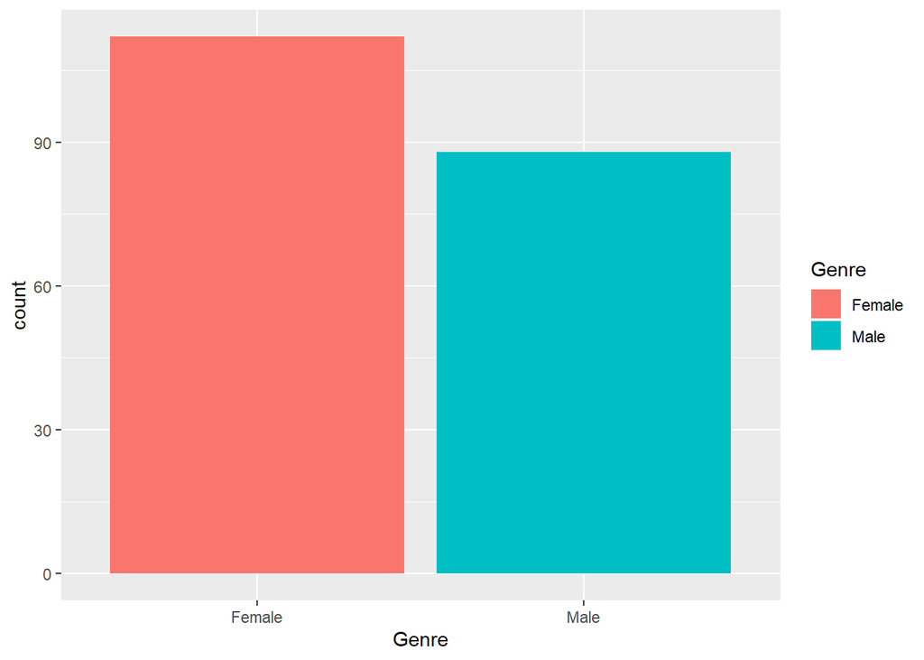

```r
ggplot(df, aes(x=Genre, fill= Genre)) + geom_bar()
```

```r
print(table(df$Genre))
```

```
##
## Female   Male
##    112     88
```

```r
print(paste('% de mujeres respecto al total: ', (length(df[df$Genre == 'Female', ]$Genre)/ length(df$Genre))*100.0))
```

```
## [1] "% de mujeres respecto al total:  56"
```

Se comprueba un cierto balanceo del dataset hacia las mujeres, pero poco significativo. Vamos a ver visualmente la distribución de las tres variables.

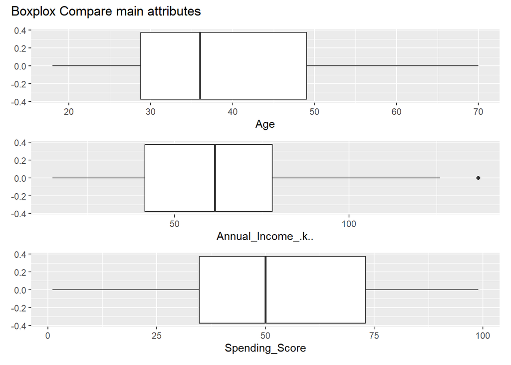

```r
p1 <- ggplot(data=df,aes(x=Age))+geom_boxplot()
p2 <- ggplot(data=df,aes(x=Annual_Income_.k..))+geom_boxplot()
p3 <- ggplot(data=df,aes(x=Spending_Score))+geom_boxplot()

(p1 / p2 / p3) + plot_annotation(title = 'Boxplox Compare main attributes')
```

```r
summary(df$Age)[3:4]
```

```
## Median   Mean
##  36.00  38.85
```

En efecto, vemos una diferencia diferencia entre media y mediana que no obstante, siendo de casi 3 años **no representa una gran desviación de la muestra**.

El resto de variables se encuentran bastante centradas, aunque en los ingresos anuales vemos un dato extremo. Vamos a examinarlo en detalle.

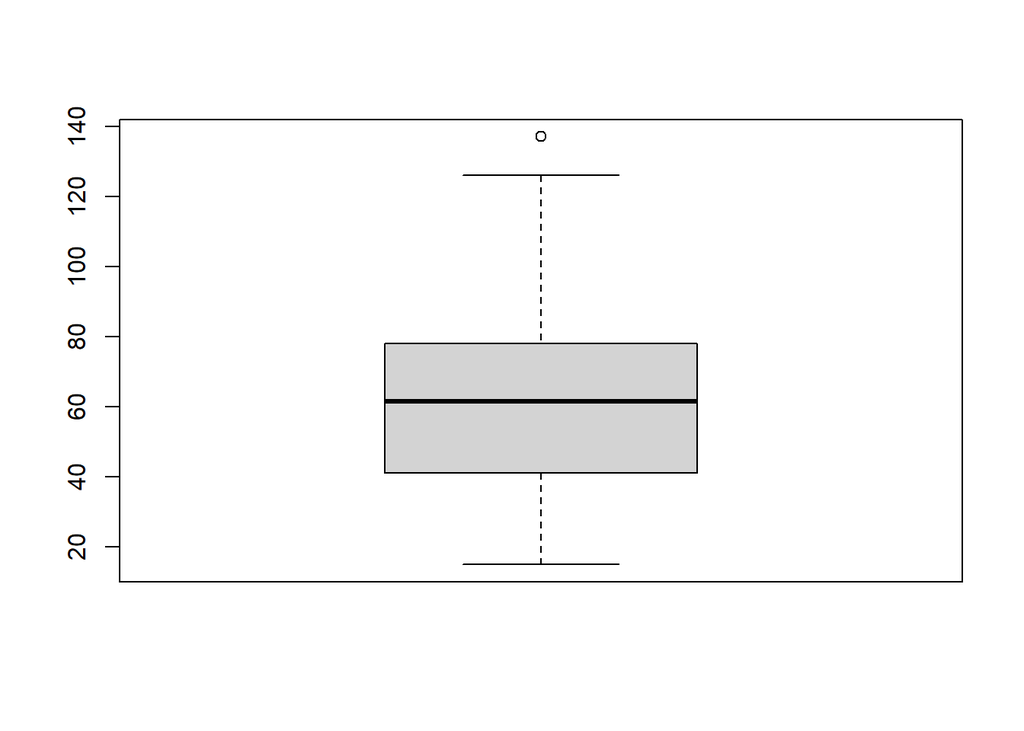

```r
out <- boxplot(df$Annual_Income_.k..)$out
```

```r
df[df$Annual_Income_.k..== 137, ]
```

```
##     CustomerID Genre Age Annual_Income_.k.. Spending_Score
## 199        199  Male  32                137             18
## 200        200  Male  30                137             83
```

Corresponden a dos valores de 137k de ingresos. Siendo un valor elevado, **no podemos considerarlo un error**, por lo que no tomaremos medidas adicionales.

Examinemos ahora la distribución de los datos

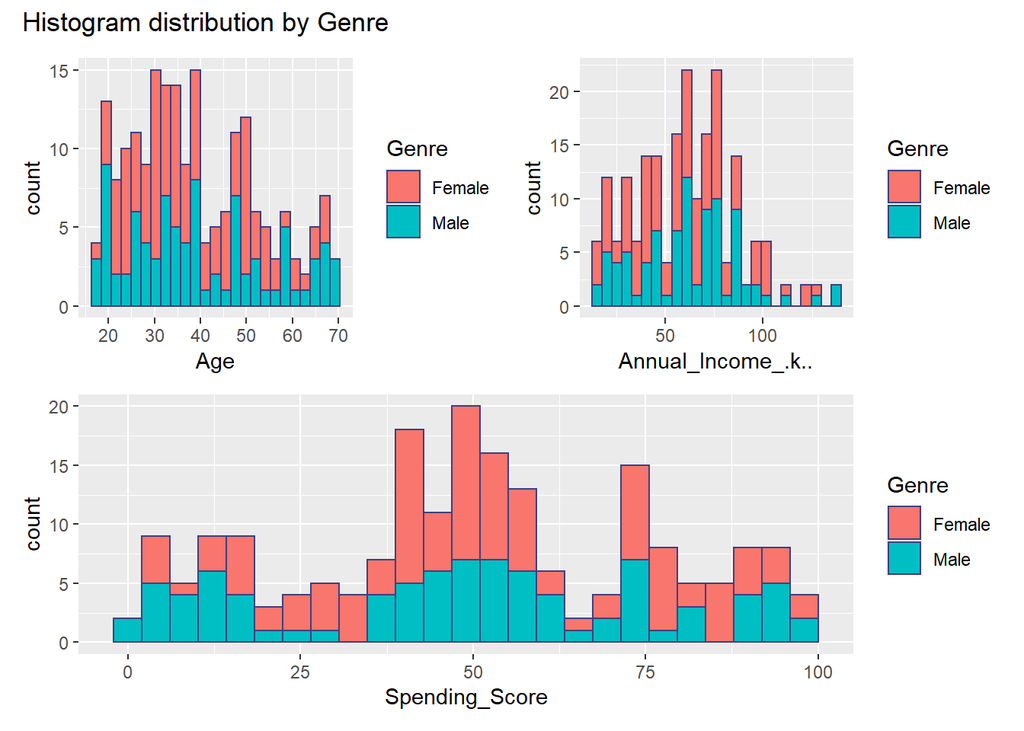

```r
color <- "#404080"
p1 <- ggplot(data=df,aes(x=Age, fill=Genre))+ geom_histogram(bins = 25, color=color)
p2 <- ggplot(data=df,aes(x=Annual_Income_.k.., fill=Genre))+ geom_histogram(bins = 25, color=color)
p3 <- ggplot(data=df,aes(x=Spending_Score, fill=Genre))+ geom_histogram(bins = 25, color=color)

(p1 | p2) / p3 + plot_annotation(title = 'Histogram distribution by Genre')
```

En la visualización de las tres variables, **no se aprecia normalidad** en las muestras.Es interesante ver como el valor del spending_score muestra valores máximos alrededor de la puntuación media, cosa que no ocurre en los hombres, que muestran una distribución más monótona. Los valores de edad se encuentran bastante bien representados, decayendo pasado los 60 años.

### 4.4.2 Escalado

```r
print('Valores extremos de Ingresos anuales: '); print(summary(df$Annual_Income_.k..)[c(1,6)])
```

```
## [1] "Valores extremos de Ingresos anuales: "
```

```
## Min. Max.
##   15  137
```

```r
print('Valores extremos de Puntuación del gasto: '); print(summary(df$ Spending_Score)[c(1,6)])
```

```
## [1] "Valores extremos de Puntuación del gasto: "
```

```
## Min. Max.
##    1   99
```

```r
df.scale <- as.data.frame(scale(df[,c('Age', 'Annual_Income_.k..', 'Spending_Score')], center = T, scale = T))
#df.scale <- cbind(df[, 1:2], df.scale)
kable(head(df.scale), format = "markdown")
```

| Age | Annual_Income_.k.. | Spending_Score |
| --- | --- | --- |
| -1.4210029 | -1.734646 | -0.4337131 |
| -1.2778288 | -1.734646 | 1.1927111 |
| -1.3494159 | -1.696572 | -1.7116178 |
| -1.1346547 | -1.696572 | 1.0378135 |
| -0.5619583 | -1.658499 | -0.3949887 |
| -1.2062418 | -1.658499 | 0.9990891 |

```r
head(df.scale)
```

```
##          Age Annual_Income_.k.. Spending_Score
## 1 -1.4210029          -1.734646     -0.4337131
## 2 -1.2778288          -1.734646      1.1927111
## 3 -1.3494159          -1.696572     -1.7116178
## 4 -1.1346547          -1.696572      1.0378135
## 5 -0.5619583          -1.658498     -0.3949887
## 6 -1.2062418          -1.658498      0.9990891
```

Hemos eliminado las variables que contienen el ID y el sexo, ya que no son necesarias y **los algoritmos de clasificación no trabajan con variables categóricas**.

### 4.4.3 Clusterización

Vamos a aplicar el algoritmo de **K-means** para encontrar que grupos podemos tener en el dataset. Para la evaluación de la calidad del proceso de agregación utilizaremos la función **silhouette**.

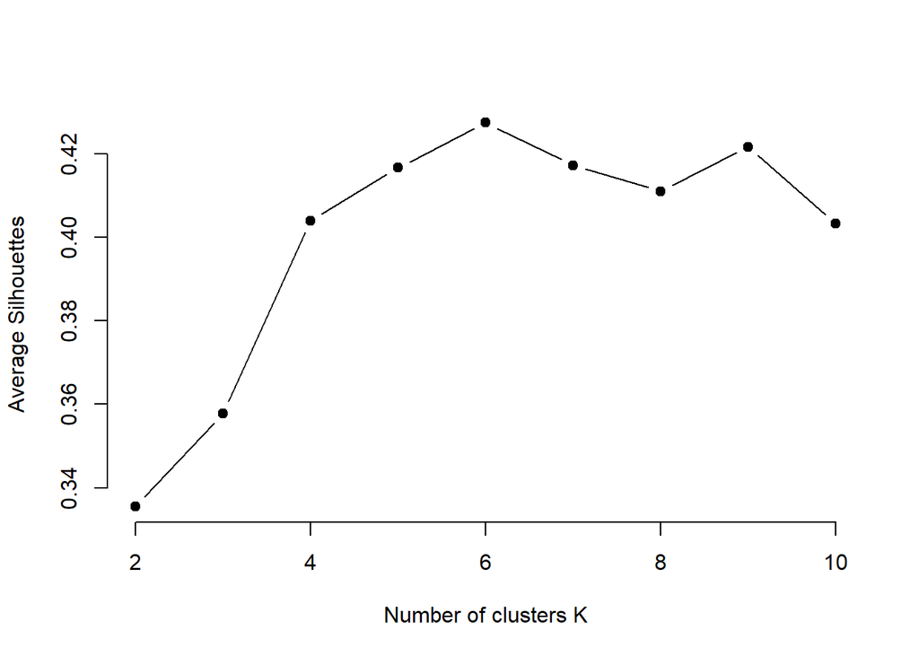

```r
set.seed(123)
d <- daisy(df.scale)
resultados.s <- rep(0,10)
resultados.w <- rep(0,10)
for (i in 2:10){
  fit <- kmeans(df.scale, i, nstart = 25)
  y_cluster <- fit$cluster
  sk <- silhouette(y_cluster, d)
  resultados.s[i] <- mean(sk[,3])
  resultados.w[i] <- sum(fit$withinss)
}
plot(2:10, resultados.s[2:10],
     #type = "o", col="blue", pch=0,
      type = "b", pch = 19, frame = FALSE,
     xlab= "Number of clusters K", ylab="Average Silhouettes")
```

Encontramos que el mejor valor lo obtenemos para 6 agrupaciones. Contrastaremos el número de clústers encontrado con la visualización de la medida por el método del Codo.

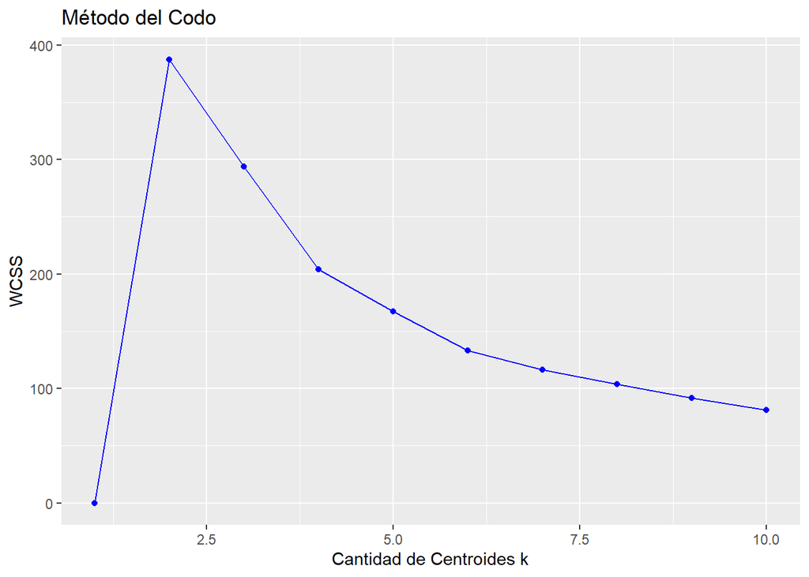

```r
ggplot() + geom_point(aes(x = 1:10, y = resultados.w), color = 'blue') +
  geom_line(aes(x = 1:10, y = resultados.w), color = 'blue') +
  ggtitle("Método del Codo") +
  xlab('Cantidad de Centroides k') +
  ylab('WCSS')
```

Repetiremos las pruebas con **Calinski-Harabasz** y otra vez la silueta media, pero utilizando kmeansruns.

```r
library(fpc)
fit_ch  <- kmeansruns(df.scale, krange = 2:10, criterion = "ch")
print(paste('Mejor valor según Calinski-Harabasz: ', fit_ch$bestk))
```

```
## [1] "Mejor valor según Calinski-Harabasz:  6"
```

```r
fit_asw <- kmeansruns(df.scale, krange = 2:10, criterion = "asw")
print(paste('Mejor valor según la silueta media: ', fit_asw$bestk))
```

```
## [1] "Mejor valor según la silueta media:  6"
```

Tanto Calisnski-Harabasz, como el valor medio de siluette, nos muestra que el mejor valor lo tenemos con 6 clusteres.

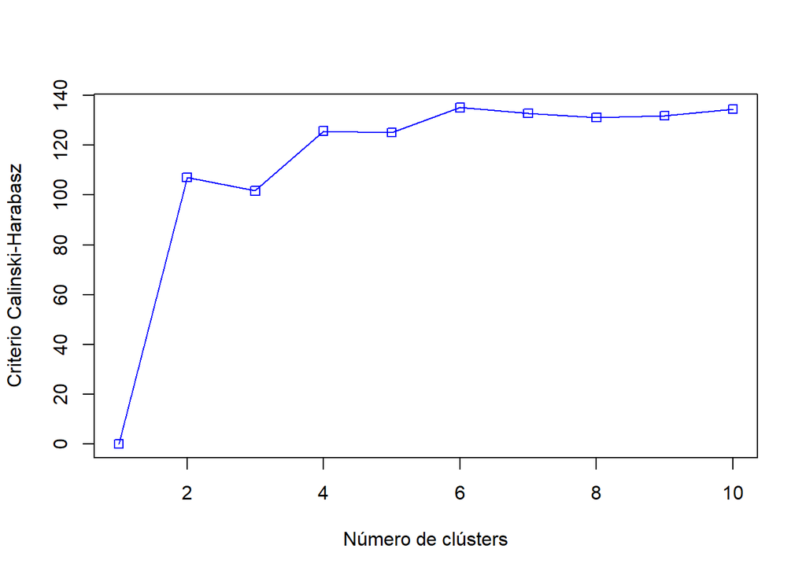

```r
plot(1:10,fit_ch$crit,type="o",col="blue",pch=0,xlab="Número de clústers",ylab="Criterio Calinski-Harabasz")
```

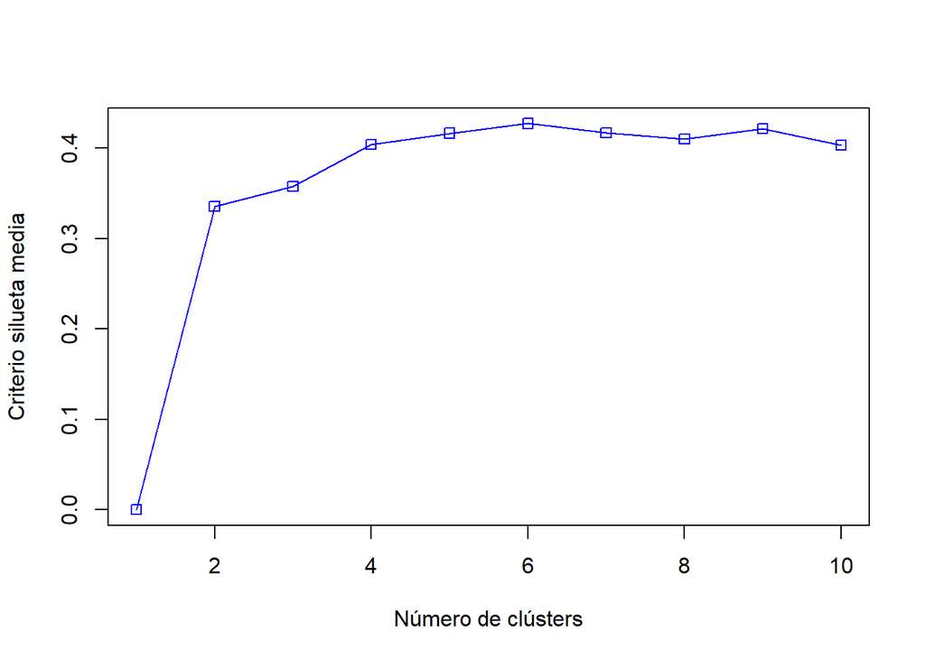

```r
plot(1:10,fit_asw$crit,type="o",col="blue",pch=0,xlab="Número de clústers",ylab="Criterio silueta media")
```

Una vez concensuado que el valor de k=6 parece ser el mejor para agrupar los datos del dataset, visualizaremos los resultados.

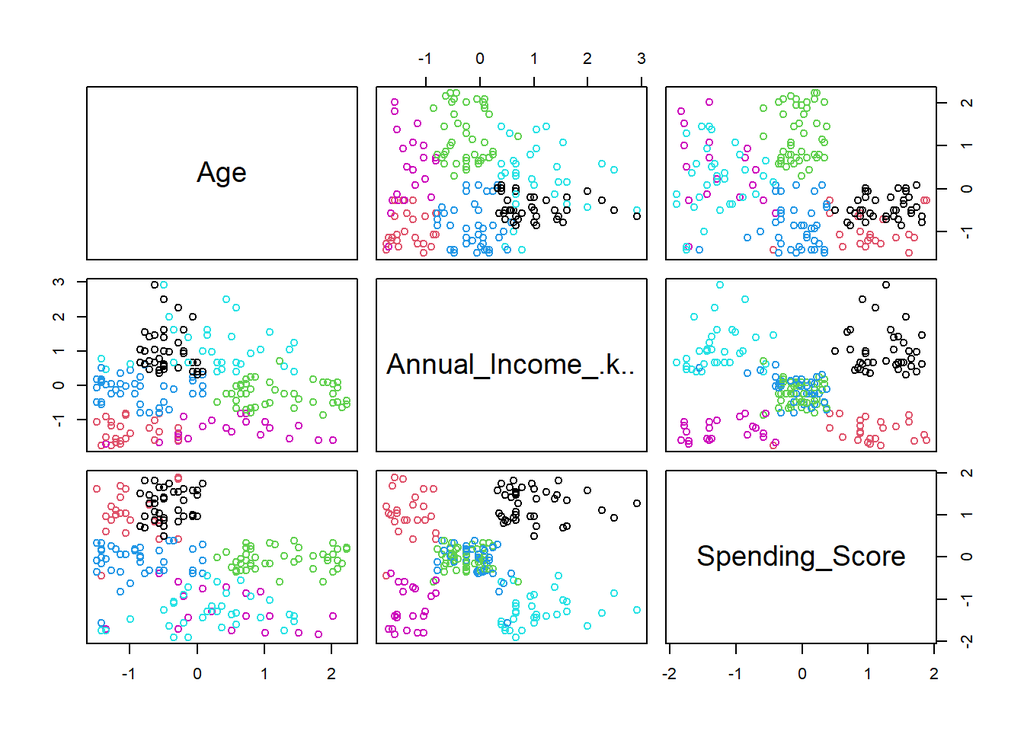

```r
k <- 6
cl <- kmeans(df.scale, k)
pairs(df.scale, col= cl$cluster)
```

Vemos una gran **confusión** en cuanto a separación de grupos entre las variables Annual_Income_k.. y Spending_Score, sobretodo en la parte central de los datos cuesta distinguir a que grupo pertenecen las observaciones.

**Enlaces Externos**: [<https://uc-r.github.io/kmeans_clustering>](https://uc-r.github.io/kmeans_clustering)